# Assignment 3

Data Science for Biomedical Informatics (BMIN503/EPID600)

### Instructions

- Download the Rmd version of this file
- Complete the questions below in RStudio using the Rmd file as a template
- Replace text in brackets with your answers, making sure you keep executable code in chunks along with its output to answer the questions. (There is no need to keep the brackets).
- Save the Rmd document as Assignment3_*YOUR LAST NAME*.Rmd
- Create an HTML version using knitr
- Turn in completed Assignment3_*YOUR LAST NAME*.html file in Canvas under Assignments -> Assignment 3
- Your assignment **must** be in html format or it will not be graded
- Grades will be assigned according to point scheme below and computed as a percentage of total possible points
- Lateness policy: If an urgent and unforeseen circumstance comes up and you need an extension to turn in an assignment, please contact Blanca, Kuldeep or Ludwig as soon as possible. Unless there is an arrangement in place, late assignments will be scored as follows:
  - 25% of total score if 1 day late
  - 50% of total score if 2 days late
  - 75% of total score if 3 days late
  - Assignment will not be graded if 4 or more days late
- DUE DATE: 10/7/21

### Final Project - Repository

1. Fork the [Final Project Repository](https://github.com/HimesGroup/BMIN503_Final_Project) to your GitHub account, and then pull this repository as a new project on your local computer by using the *Project* menu in the upper-right-hand corner of RStudio, selecting a *New Project*, creating it via *Version Control* -> *Git* -> and entering your GitHub repository (remember to append `.git` to the copied `url`). You can now work on your final project from your computer, and easily push updates to your GitHub account, where the final version will be saved. A *Git* tab will be available that you can use to *Pull*, *Commit*, and *Push* changes between your local version and that on GitHub without having to use the command line. *(1 point for forking repository)*
2. In 2-3 sentences, describe what question you will answer for your final project and what data will you use. There is a list of public data sources at the bottom of the [Optional Reading](https://htmlpreview.github.io/?https://github.com/HimesGroup/BMIN503/blob/master/Module1_Optional_Reading.html) document that you can look through if you are having difficulty identifying public data. If you’d like help to pick a topic, please let Blanca know soon. *(2 points)*

> I’ll be using a publicly available database of sepsis gene expression (microarray) to examine changes in gene expression correlated with 28-d mortality, with a goal to design a model to predict mortality based on gene expression patterns.
3. What three faculty/staff (name, title, division/department) have you met or are planning to meet to discuss your project? *(2 points)*

> Nuala Meyer, Pulm & Critical Care, Associate Professor, Hosp of Univ of PA Daniel Beiting, Assistant Professor, University of Pennsylvania, School of Veterinary Medicine Michael Shashaty, Pulm & Critical Care, Associate Professor, Hosp of the Univ of PA

### Cleaning and Transforming data, Descriptive Statistics and Regression

4. Install and load the `nycflights13` package to do this problem. This package includes the flights dataset, which contains information on 336,776 flights that departed from New York City in 2013. If you need more guided practice with `dplyr`, beyond what we did in class, you can go through this.

```r
library(tidyverse)
library(nycflights13)
library(gtsummary)
library(modelsummary)

head(flights)
```

```
## # A tibble: 6 × 19
##    year month   day dep_time sched_dep_time dep_delay arr_time sched_arr_time
##   <int> <int> <int>    <int>          <int>     <dbl>    <int>          <int>
## 1  2013     1     1      517            515         2      830            819
## 2  2013     1     1      533            529         4      850            830
## 3  2013     1     1      542            540         2      923            850
## 4  2013     1     1      544            545        -1     1004           1022
## 5  2013     1     1      554            600        -6      812            837
## 6  2013     1     1      554            558        -4      740            728
## # … with 11 more variables: arr_delay <dbl>, carrier <chr>, flight <int>,
## #   tailnum <chr>, origin <chr>, dest <chr>, air_time <dbl>, distance <dbl>,
## #   hour <dbl>, minute <dbl>, time_hour <dttm>
```

```r
flights <- flights
```

[vignette](https://cran.r-project.org/web/packages/dplyr/vignettes/dplyr.html). Use `dplyr` to answer the following questions by inserting code below each bullet to provide the answer directly. *(10 points)* + Which airports included in the dataset have flights originating from NYC? Which airport had the most departing flights?

#### the most departing flights is NEWARK (120,835 flights)

```r
flights %>% group_by(origin)%>%
  summarize(n=n())%>%
  arrange(n)
```

```
## # A tibble: 3 × 2
##   origin      n
##   <chr>   <int>
## 1 LGA    104662
## 2 JFK    111279
## 3 EWR    120835
```

- Of the flights that departed during the second half of the year from La Guardia (LGA), how many unique tailnum contained “SW” or “NW”?

```r
# first, filter for just the second half of the year and just laguardi
df_NW <- flights %>% filter(month >= 6) %>%
  filter(origin=="LGA") %>%
  arrange(tailnum) %>%
  filter(grepl("NW", tailnum)) %>%
  distinct(tailnum)

# 60 flights with "NW"

df_SW <- flights %>% filter(month >= 6) %>%
  filter(origin=="LGA") %>%
  arrange(tailnum) %>%
  filter(grepl("SW", tailnum)) %>%
  distinct(tailnum)

# 103 flights with "SW"

# check overlap in case there are NW/SW
intersect(df_NW$tailnum, df_SW$tailnum)
```

```
## character(0)
```

```
+ Which destinations had only one flight per month, for at least one month during the year?
```

#### there are six destinations that had only one departure in at least one month

#### ALB, EYW, LEX, LGA, MYR and SBN

```r
flights %>% group_by(dest, month) %>%
  summarise(n = n()) %>%
  filter(n==1) %>%
  arrange(dest)
```

```
## # A tibble: 10 × 3
## # Groups:   dest [6]
##    dest  month     n
##    <chr> <int> <int>
##  1 ALB      10     1
##  2 EYW       1     1
##  3 EYW       4     1
##  4 LEX      11     1
##  5 LGA       7     1
##  6 MYR       4     1
##  7 MYR       6     1
##  8 SBN       8     1
##  9 SBN      10     1
## 10 SBN      12     1
```

```
+ Was the mean departure delay time per carrier related to the total number of flights per carrier? The answer should show a plot and use one sentence to address this question qualitatively.
```

#### the mean departure delay is not relatived to the total number of flights per carrier

```r
colnames(flights)
```

```
##  [1] "year"           "month"          "day"            "dep_time"
##  [5] "sched_dep_time" "dep_delay"      "arr_time"       "sched_arr_time"
##  [9] "arr_delay"      "carrier"        "flight"         "tailnum"
## [13] "origin"         "dest"           "air_time"       "distance"
## [17] "hour"           "minute"         "time_hour"
```

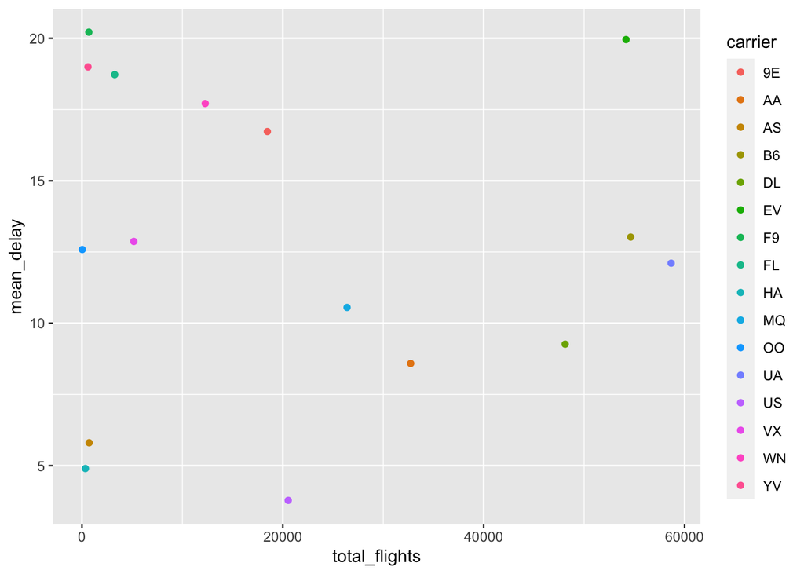

```r
# variables of interest are: "dep_delay", "carrier", "flight"
#calculate mean departure delay per carrier, summarize total flights, plot x vs. y by carrier

delay <- group_by(flights, carrier) %>%
        summarise(mean_delay = mean(dep_delay, na.rm=TRUE), total_flights  = n())
ggplot(data = delay, aes(x = total_flights, y = mean_delay, color=carrier)) + geom_point()
```

```r
# plot (mean departure delay time per carrier) vs (total number of flights per carrier)
```

[output not shown]

#### The mean delay time increases as the departure time gets later, ie. flights leaving around 5AM leave more promptly, and flights leaving around midnight have a greater departure delay.

```r
# variables to work with are "dep_delay", "dep_time", "origin"
# need to calculate mean delay time for a given departure time

mean_delay_time_of_dept <- flights %>%
  select(dep_delay, dep_time, origin) %>%
  group_by(origin, dep_time) %>%
  summarise(mean_delay = mean(dep_delay, na.rm = TRUE), count =  n())
```

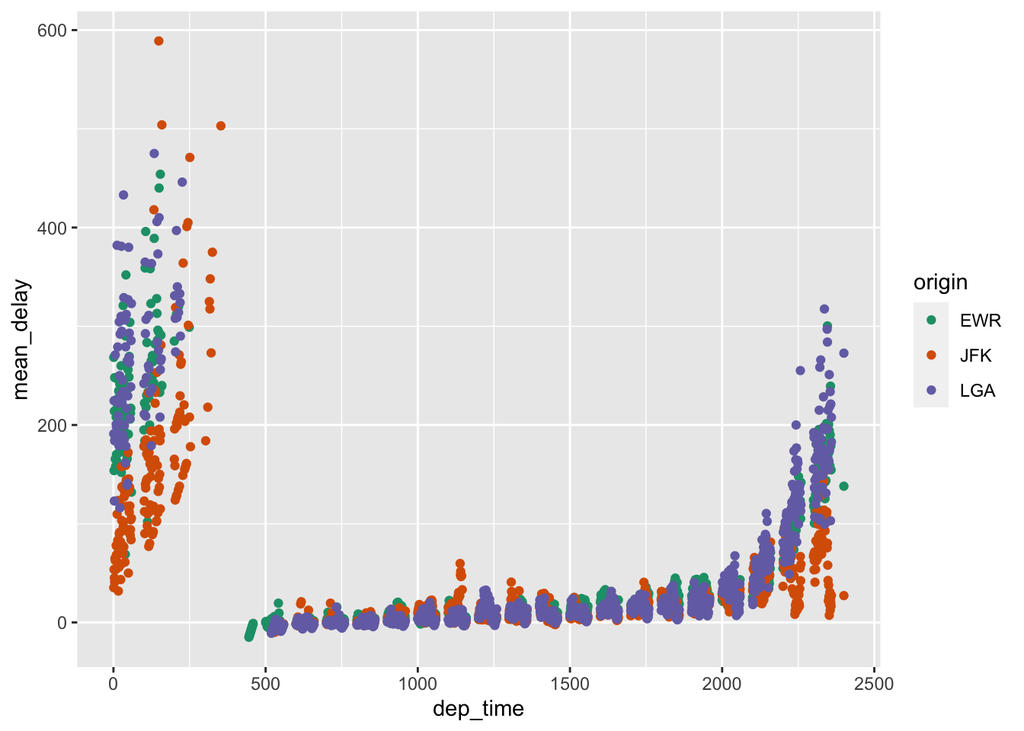

```r
ggplot(data = mean_delay_time_of_dept, aes(x = dep_time, y = mean_delay, color=origin)) +
    geom_point() + scale_color_brewer(palette="Dark2")
```

5. Load the `MASS` package, which contains the [birthwt](https://stat.ethz.ch/R-manual/R-devel/library/MASS/html/birthwt.html) dataset, to answer the following questions. We will work toward identifying variables that are associated with low birthweight, both as a dichotomous outcome and a continuous one. NOTE: The `MASS` package contains a `select` command that may compete with that from `dplyr`. If you have `dplyr` and `MASS` loaded simultaneously and want to use `dplyr`’s `select`, do it explicitly. For example, use `dplyr::select` rather than `select`. *(9 points)*
   - Take a look at the `birthwt` dataset (e.g., using `str()`) to get a sense of variables it contains. We will use the variables `low` and `bwt` as outcomes and `age`, `race`, `smoke`, `ht`, `ptl` as predictors. Create a new dataset `birthwt.clean` containing only the variables we are interested in, where 1) the variables `low`, `ht`, and `ptl` are renamed `low.birth.wt`, `hypertension`, and `prem.labor`, respectively; 2) all integer categories (i.e., `low.birth.wt`, `race`, `smoke`, `hypertension`, `prem.labor`) are converted to factors with intuitive labels; 3) the `race` variable does not include the `other` category; and 4) the `ptl` variable is dichotomized into two levels based on a positive or negative history of previous premature labor.
   - Perform bivariate analysis for the resulting `age` and `smoke` variables you created as predictors and `low.birth.wt` and `bwt` as outcomes. Include appropriate plots that look at the pairwise relationships between the outcomes and each predictor and fit appropriate regression models between each outcome and each predictor individually. Are there differences between the results for each outcome?
   - Create multivariable regression models for `low.birth.wt` and `bwt` using `age`, `race`, `smoke`, `hypertension`, and `prem.labor` as predictors. What factors are significantly associated with the birth weight outcomes?

```r
# load the MASS package
library(MASS)
birthwt <- birthwt

str(birthwt)
```

```
## 'data.frame':    189 obs. of  10 variables:
##  $ low  : int  0 0 0 0 0 0 0 0 0 0 ...
##  $ age  : int  19 33 20 21 18 21 22 17 29 26 ...
##  $ lwt  : int  182 155 105 108 107 124 118 103 123 113 ...
##  $ race : int  2 3 1 1 1 3 1 3 1 1 ...
##  $ smoke: int  0 0 1 1 1 0 0 0 1 1 ...
##  $ ptl  : int  0 0 0 0 0 0 0 0 0 0 ...
##  $ ht   : int  0 0 0 0 0 0 0 0 0 0 ...
##  $ ui   : int  1 0 0 1 1 0 0 0 0 0 ...
##  $ ftv  : int  0 3 1 2 0 0 1 1 1 0 ...
##  $ bwt  : int  2523 2551 2557 2594 2600 2622 2637 2637 2663 2665 ...
```

```r
#`low` and `bwt` as outcomes and `age`, `race`, `smoke`, `ht`, `ptl` as predictors
```

```r
# 1) Create a new dataset `birthwt.clean` containing only the variables we are interested in and rename the variables `low`, `ht`, and `ptl` are renamed `low.birth.wt`, `hypertension`, and `prem.labor`, respectively;
# 2) all integer categories (i.e., `low.birth.wt`, `race`, `smoke`, `hypertension`, `prem.labor`) are
# converted to factors with intuitive labels;
# 3) the `race` variable does not include the `other` category; and
# 4) the `ptl` variable is dichotomized into two levels based on a positive or negative history of previous premature labor.

birthwt.clean <- birthwt %>% dplyr::select(low, bwt, age, race, smoke, ht, ptl) %>%
  dplyr::rename("low.birth.wt"=low, "hypertension"=ht, "prem.labor"=ptl)

birthwt.clean$prem.labor <- ifelse(birthwt.clean$prem.labor>0, 1, 0)

birthwt.clean <- birthwt.clean %>% mutate(low.birth.wt=factor(low.birth.wt, labels = c("no", "yes"))) %>%
  dplyr::mutate(race = factor(race, levels = c(1:3), labels = c("white","black",NA))) %>%
  dplyr::mutate(smoke = factor(smoke, labels= c("nonsmoker", "smoker"))) %>%
  dplyr::mutate(hypertension= factor(hypertension, labels = c("normotensive", "hypertensive"))) %>%
  dplyr::mutate(prem.labor = factor(prem.labor,labels = c("negative", "positive")))

head(birthwt.clean)
```

```
##    low.birth.wt  bwt age  race     smoke hypertension prem.labor
## 85           no 2523  19 black nonsmoker normotensive   negative
## 86           no 2551  33  <NA> nonsmoker normotensive   negative
## 87           no 2557  20 white    smoker normotensive   negative
## 88           no 2594  21 white    smoker normotensive   negative
## 89           no 2600  18 white    smoker normotensive   negative
## 91           no 2622  21  <NA> nonsmoker normotensive   negative
```

```r
# Perform bivariate analysis for the resulting `age` and `smoke` variables you created as predictors and `low.birth.wt` and `bwt` as outcomes. Include appropriate plots that look at the pairwise relationships between the outcomes and each predictor and fit appropriate regression models between each outcome and each predictor individually. Are there differences between the results for each outcome?
# age = continuous predictor
# smoke = categorical predictor
# low.birth.wt = binary outcome
# btw = continuous outcome

model1 <- glm(low.birth.wt~age, birthwt.clean, family=binomial)
summary(model1)
```

```
##
## Call:
## glm(formula = low.birth.wt ~ age, family = binomial, data = birthwt.clean)
##
## Deviance Residuals:
##     Min       1Q   Median       3Q      Max
## -1.0402  -0.9018  -0.7754   1.4119   1.7800
##
## Coefficients:
##             Estimate Std. Error z value Pr(>|z|)
## (Intercept)  0.38458    0.73212   0.525    0.599
## age         -0.05115    0.03151  -1.623    0.105
##
## (Dispersion parameter for binomial family taken to be 1)
##
##     Null deviance: 234.67  on 188  degrees of freedom
## Residual deviance: 231.91  on 187  degrees of freedom
## AIC: 235.91
##
## Number of Fisher Scoring iterations: 4
```

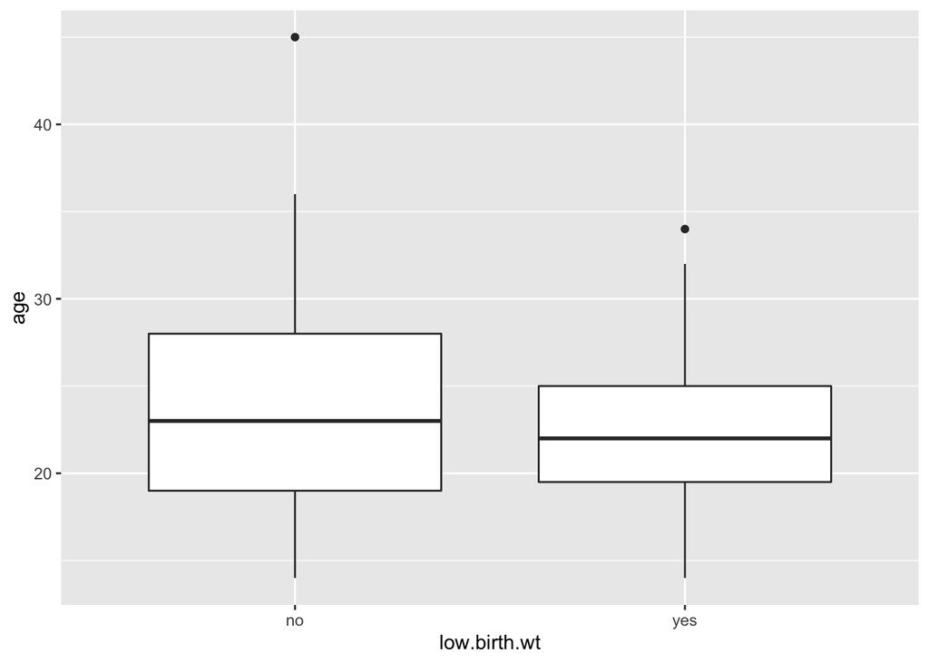

```r
ggplot(birthwt.clean, aes(x=low.birth.wt, y=age))+geom_boxplot()
```

```r
model2 <- glm(low.birth.wt~smoke,birthwt.clean, family=binomial)
summary(model2)
```

```
##
## Call:
## glm(formula = low.birth.wt ~ smoke, family = binomial, data = birthwt.clean)
##
## Deviance Residuals:
##     Min       1Q   Median       3Q      Max
## -1.0197  -0.7623  -0.7623   1.3438   1.6599
##
## Coefficients:
##             Estimate Std. Error z value Pr(>|z|)
## (Intercept)  -1.0871     0.2147  -5.062 4.14e-07 ***
## smokesmoker   0.7041     0.3196   2.203   0.0276 *
## ---
## Signif. codes:  0 '***' 0.001 '**' 0.01 '*' 0.05 '.' 0.1 ' ' 1
##
## (Dispersion parameter for binomial family taken to be 1)
##
##     Null deviance: 234.67  on 188  degrees of freedom
## Residual deviance: 229.80  on 187  degrees of freedom
## AIC: 233.8
##
## Number of Fisher Scoring iterations: 4
```

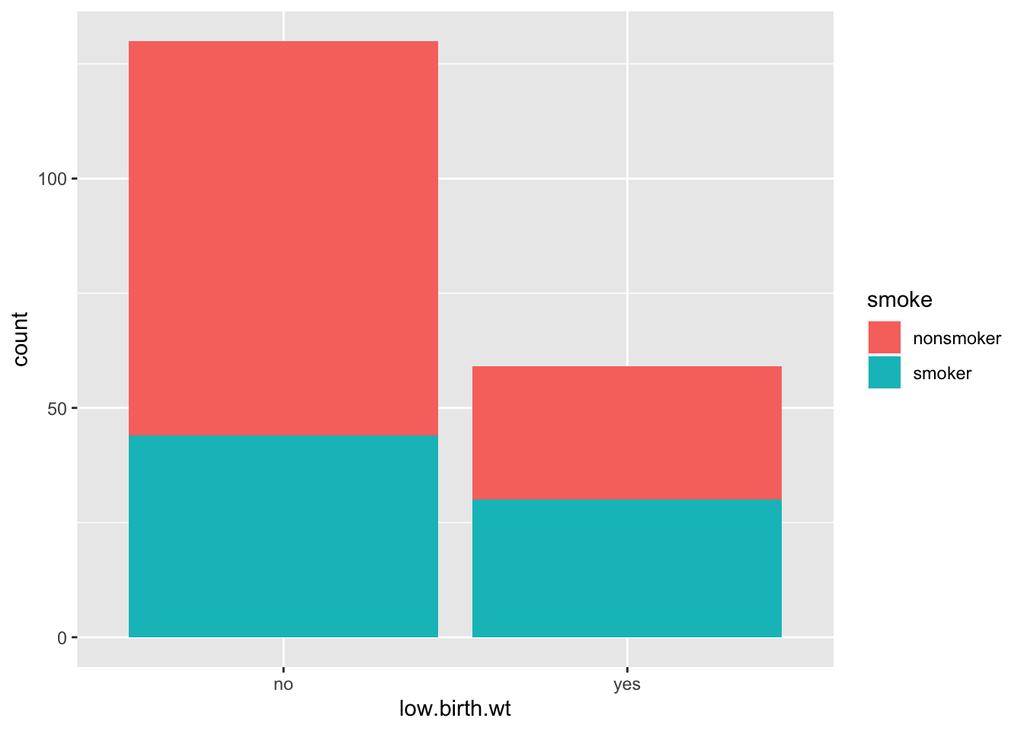

```r
ggplot(birthwt.clean, aes(x=low.birth.wt, fill=smoke))+geom_bar()
```

```r
model3 <- glm(bwt~age, birthwt.clean, family = "gaussian")
tbl_regression(model3)
```

| **Characteristic** | **Beta** | **95% CI**<sup>1</sup> | **p-value** |
| --- | --- | --- | --- |
| age | 12 | -7.2, 32 | 0.2 |

<sup>*1*</sup> CI = Confidence Interval

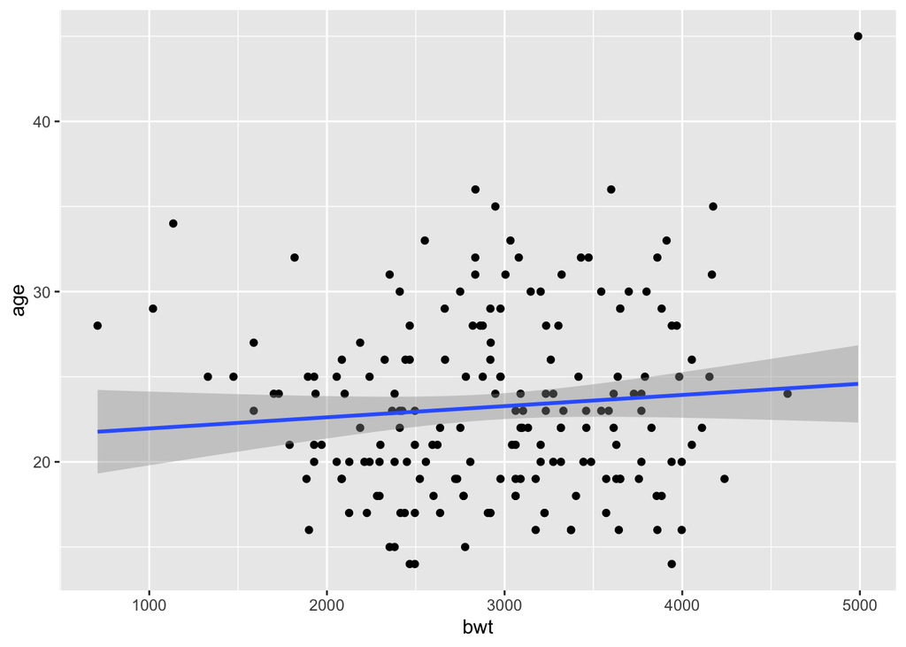

```r
ggplot(birthwt.clean, aes(x=bwt, y=age))+geom_point()+geom_smooth(method='lm')
```

```r
model4 <- glm(bwt~smoke,birthwt.clean, family = "gaussian")
msummary(model4)
```

|  | Model 1 |
| --- | --- |
| (Intercept) | 3055.696 |
|  | (66.933) |
| smokesmoker | −283.777 |
|  | (106.969) |
| Num.Obs. | 189 |
| AIC | 3026.1 |
| BIC | 3035.9 |
| Log.Lik. | −1510.069 |

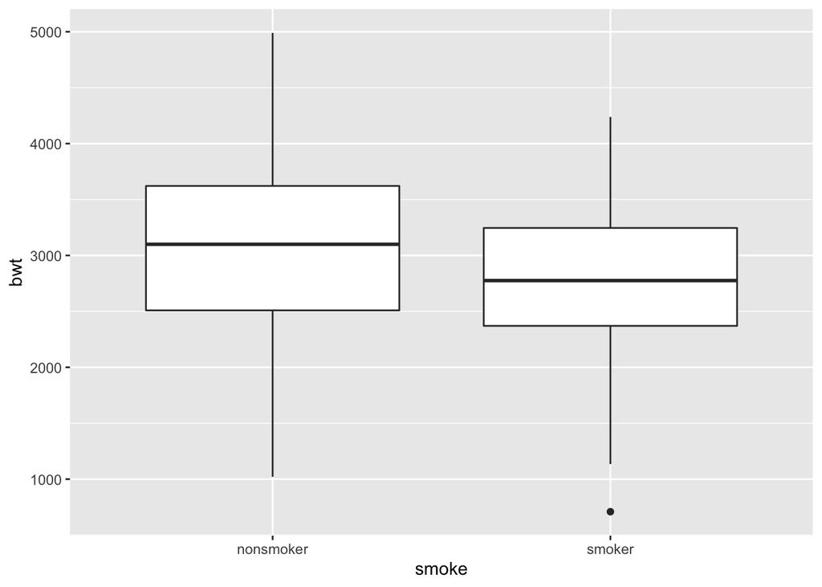

```r
ggplot(birthwt.clean, aes(x=smoke, y=bwt))+geom_boxplot()
```

```r
# + Create multivariable regression models for `low.birth.wt` and `bwt` using `age`, `race`, `smoke`, `hypertension`, and `prem.labor` as predictors. What factors are significantly associated with the birth weight outcomes?

multimodel <- glm(low.birth.wt ~ age+race+smoke+hypertension+prem.labor, data=birthwt.clean, family=binomial)
tbl_regression(multimodel)
```

| **Characteristic** | **log(OR)**<sup>1</sup> | **95% CI**<sup>1</sup> | **p-value** |
| --- | --- | --- | --- |
| age | -0.06 | -0.13, 0.01 | 0.11 |
| race |  |  |  |
| white | — | — |  |
| black | 0.92 | -0.08, 1.9 | 0.069 |
| NA | 1.0 | 0.14, 1.8 | 0.024 |
| smoke |  |  |  |
| nonsmoker | — | — |  |
| smoker | 0.91 | 0.15, 1.7 | 0.021 |
| hypertension |  |  |  |
| normotensive | — | — |  |
| hypertensive | 1.2 | 0.00, 2.5 | 0.051 |
| prem.labor |  |  |  |
| negative | — | — |  |
| positive | 1.4 | 0.57, 2.3 | 0.001 |

<sup>*1*</sup> OR = Odds Ratio, CI = Confidence Interval

```r
multimodel2 <- glm(bwt ~ age+race+smoke+hypertension+prem.labor, data=birthwt.clean, family=gaussian)
summary(multimodel2)
```

```
##
## Call:
## glm(formula = bwt ~ age + race + smoke + hypertension + prem.labor,
##     family = gaussian, data = birthwt.clean)
##
## Deviance Residuals:
##      Min        1Q    Median        3Q       Max
## -2370.63   -425.35     -0.15    499.57   1515.16
##
## Coefficients:
##                          Estimate Std. Error t value Pr(>|t|)
## (Intercept)              3240.813    257.088  12.606  < 2e-16 ***
## age                         5.200      9.672   0.538 0.591464
## raceblack                -398.784    154.031  -2.589 0.010404 *
## raceNA                   -405.050    117.898  -3.436 0.000732 ***
## smokesmoker              -362.468    110.805  -3.271 0.001281 **
## hypertensionhypertensive -382.364    202.719  -1.886 0.060864 .
## prem.laborpositive       -330.315    139.267  -2.372 0.018745 *
## ---
## Signif. codes:  0 '***' 0.001 '**' 0.01 '*' 0.05 '.' 0.1 ' ' 1
##
## (Dispersion parameter for gaussian family taken to be 458214.5)
##
##     Null deviance: 99969656  on 188  degrees of freedom
## Residual deviance: 83395037  on 182  degrees of freedom
## AIC: 3008.9
##
## Number of Fisher Scoring iterations: 2
```